# Static spatial data (raster, vector); geostatistics, Machine learning for spatial prediction

Edzer Pebesma

2/16/2022

## Geostatistics

We will work with the soil data provided by the course managers:

```r
library(sf)
(s = st_read("re_ca_topsoil.geojson"))
```

```
## Simple feature collection with 220 features and 21 fields
## Geometry type: POINT
## Dimension:     XY
## Bounding box:  xmin: 13.77767 ymin: 40.05354 xmax: 15.69943 ymax: 41.48791
## Geodetic CRS:  WGS 84
## First 10 features:
##    P_code UC_sigla ID_profile Layer  Depth thickness theta_r_VG theta_s_VG
## 1    8000     <NA>     CP68_1     a   0-10        10          0  0.4834958
## 2    8001     <NA>     CP5_53     a   0-30        30          0  0.4608782
## 3    8002     <NA> LS_Cp62_93     a   0-20        20          0  0.4704716
## 4    8003     <NA>   UOT52_47     a   0-50        50          0  0.4186500
## 5    8004     <NA>     CP4_21     a   0-30        30          0  0.4412993
## 6    8005     <NA>    Cp61_44     a 0-26.5        27          0  0.4279736
## 7    8006     <NA>    CP11_20     a   0-40        40          0  0.4266058
## 8    8007     <NA>   Cp61_101     a 0-11.5        12          0  0.4926677
```

[output cut: 35 more lines]

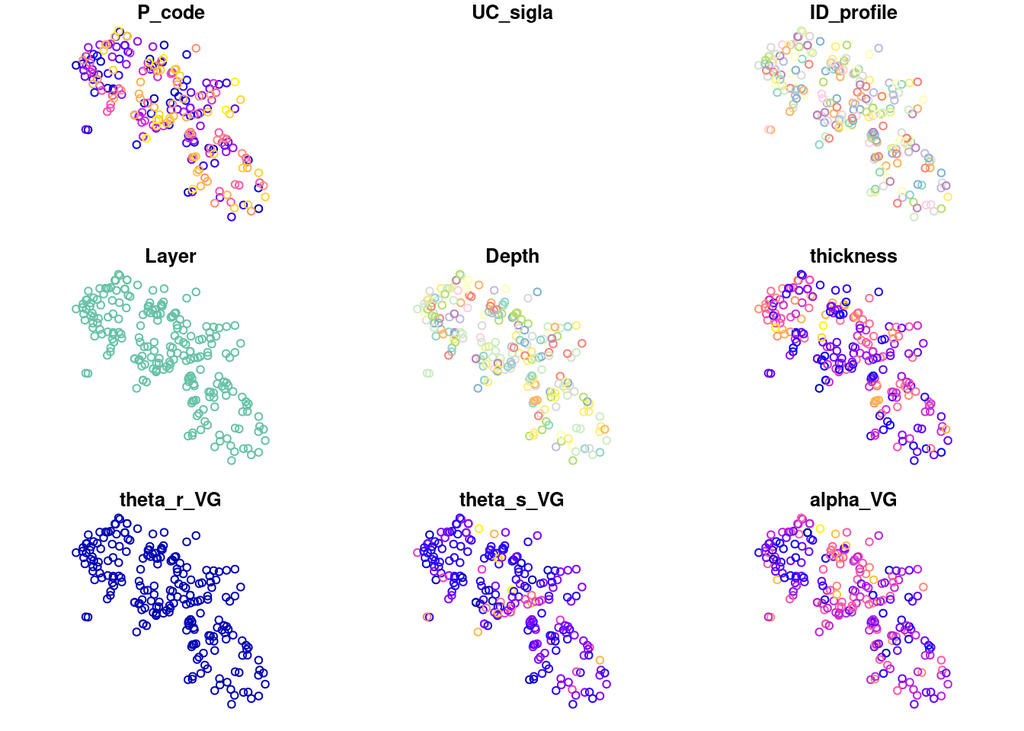

```r
plot(s)
```

We can look at one of the variables, and try to interpolate this on a regular grid. For this, we first need to estimate a *variogram model* from a *sample variogram*, then we need a regular grid, then we need to interpolate at the grid points (kriging).

### sample variogram

Using the data as provided, we see

```r
library(gstat)
(v = variogram(bulk_den~1, s)) # sample variogram
```

```
##      np      dist      gamma dir.hor dir.ver   id
## 1   183  3.258151 0.02853475       0       0 var1
## 2   448  7.747504 0.02774474       0       0 var1
## 3   616 12.849362 0.03428332       0       0 var1
## 4   731 17.786052 0.03543237       0       0 var1
## 5   906 22.852893 0.03172295       0       0 var1
## 6  1019 27.855368 0.03676213       0       0 var1
## 7  1118 32.855758 0.03720777       0       0 var1
## 8  1208 37.912819 0.03831131       0       0 var1
## 9  1321 42.927025 0.04308984       0       0 var1
## 10 1388 47.972780 0.04384591       0       0 var1
## 11 1369 53.004186 0.04013334       0       0 var1
## 12 1183 58.107097 0.03953265       0       0 var1
## 13 1173 63.070224 0.04507783       0       0 var1
## 14 1040 68.120154 0.04281722       0       0 var1
## 15 1033 73.315616 0.03468188       0       0 var1
```

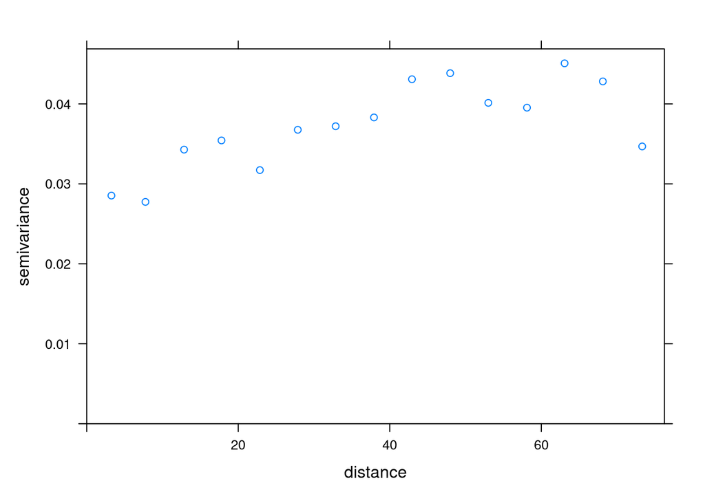

```r
plot(v)
```

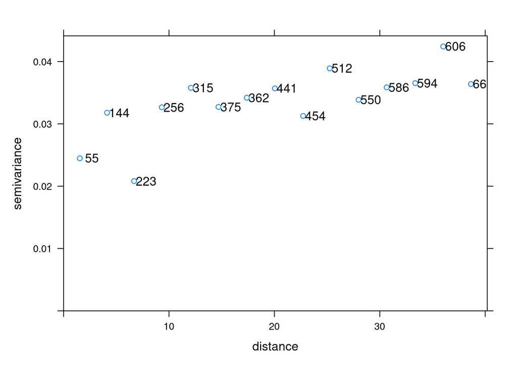

```r
v = variogram(bulk_den~1, s, cutoff = 40) # try with smaller cutoff
plot(v, plot.numbers = TRUE)
```

### variogram model

We choose an exponential model, and pick some initial values for

- nugget (.1)
- range (5; this is km)
- sill (1)

that work as initial values to a non-linear fit that uses a Newton-type optimization:

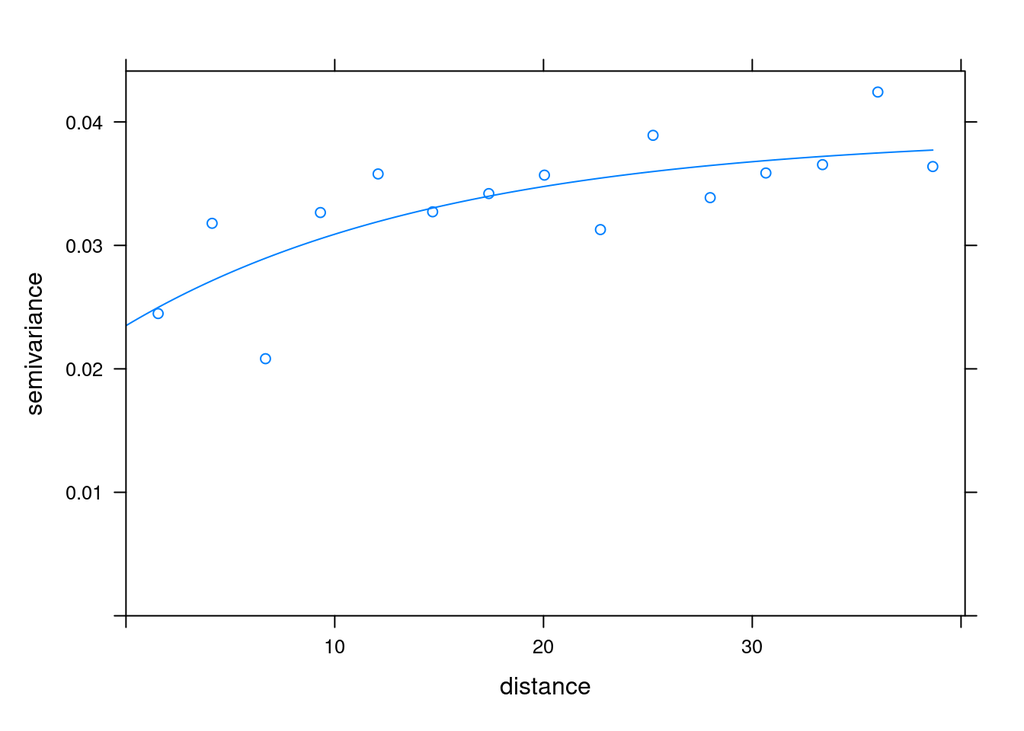

```r
v.fit = fit.variogram(v, vgm(1, "Exp", 5, .1)) # fitted model
plot(v, v.fit) # is this O.K.?
```

### regular grid

We have target locations on a regular grid, obtained by

```r
library(stars)
```

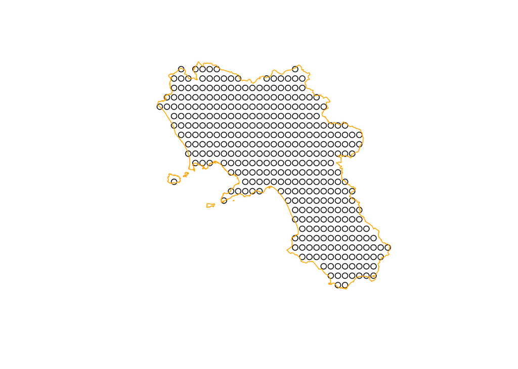

```r
r = read_sf("cosmoleps_ca.geojson") # grid points
plot(r, reset = FALSE)
roi = read_sf("roi_ca_geom.geojson")
plot(st_geometry(roi), add = TRUE, col = NA, border = 'orange')
```

which we can rasterize by

```r
ra = st_rasterize(r)
ra
```

```
## stars object with 2 dimensions and 1 attribute
## attribute(s):
##     Min. 1st Qu. Median     Mean 3rd Qu. Max.
## ID     0       0      0 84.11152  166.25  370
## dimension(s):
##   from to  offset      delta refsys point values x/y
## x    1 34  13.753  0.0625674 WGS 84 FALSE   NULL [x]
## y    1 24 41.4899 -0.0626398 WGS 84 FALSE   NULL [y]
```

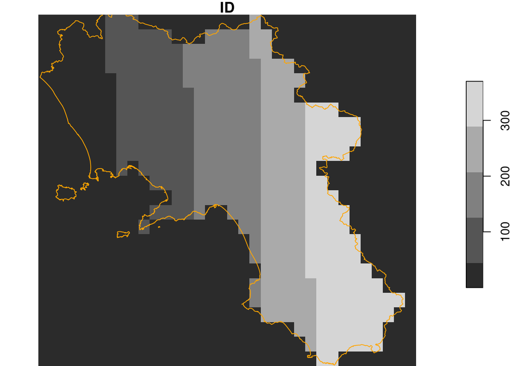

```r
plot(ra, reset = FALSE)
plot(st_geometry(roi), add = TRUE, col = NA, border = 'orange')
```

we see that cells with no points on them are assigned 0, so we need to `NA` those:

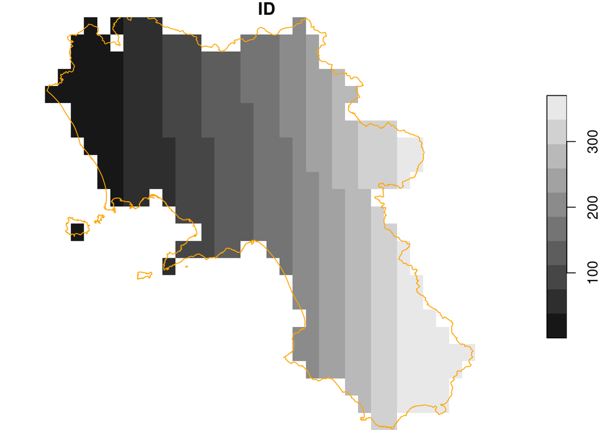

```r
ra[ra == 0] = NA
plot(ra, reset = FALSE)
plot(st_geometry(roi), add = TRUE, col = NA, border = 'orange')
```

### kriging

```r
kr = krige(bulk_den~1, s, ra, v.fit)
```

```
## [using ordinary kriging]
```

How can we find duplicate observation locations?

```r
e = st_equals(s)
e
```

```
## Sparse geometry binary predicate list of length 220, where the
## predicate was `equals'
## first 10 elements:
##  1: 1
##  2: 2
##  3: 3
##  4: 4
##  5: 5
##  6: 6
##  7: 7
##  8: 8
##  9: 9
##  10: 10
```

```r
lengths(e)
```

```
##   [1] 1 1 1 1 1 1 1 1 1 1 2 1 1 1 1 1 1 1 1 1 1 1 1 1 1 1 1 1 2 1 1 1 1 1 1 1 1
##  [38] 1 1 1 1 1 1 2 1 1 1 1 1 1 1 1 1 1 1 1 1 1 1 1 1 1 1 2 1 1 1 1 1 1 2 1 1 1
##  [75] 1 1 1 1 1 1 2 1 1 1 1 1 1 1 2 1 1 1 1 1 1 1 1 1 1 1 1 1 1 1 2 1 1 1 1 1 1
## [112] 1 1 1 1 1 1 1 1 1 1 1 1 1 1 1 1 1 1 1 1 1 1 1 1 1 1 1 2 1 1 1 1 1 1 1 1 1
## [149] 1 1 2 1 1 1 2 1 1 1 1 1 1 1 1 1 1 1 2 1 1 1 1 1 1 1 1 1 1 2 1 1 1 1 1 1 1
## [186] 1 1 1 1 1 1 1 1 1 1 1 1 1 1 1 1 1 1 1 1 1 1 1 1 1 2 1 1 1 1 1 1 1 1 1
```

```r
which(lengths(e) > 1)
```

```
##  [1]  11  29  44  64  71  81  89 105 139 151 155 167 178 211
```

Removing *all* points with an duplicate observations like we could do with

```
s = s[lengths(e) == 1,]
```

is a bit rigorous; we’d like to *only* remove the duplicate, not the *first* points (or, possibly better, we’d like to compute averages for points with more than one observations). Let us remove the *duplicate* points

```r
e[[11]]
```

```
## [1]  11 211
```

```r
e[[29]] # the second is always higher;
```

```
## [1] 29 89
```

```r
# take the second of each pair:
dupl = e[lengths(e) > 1]
w = sapply(dupl, tail, 1) # select the last from the duplicates
s_nd = s[-w,] # deselect those second
```

Let us try the kriging again:

```r
kr = krige(bulk_den~1, s_nd, ra, v.fit)
```

```
## [using ordinary kriging]
```

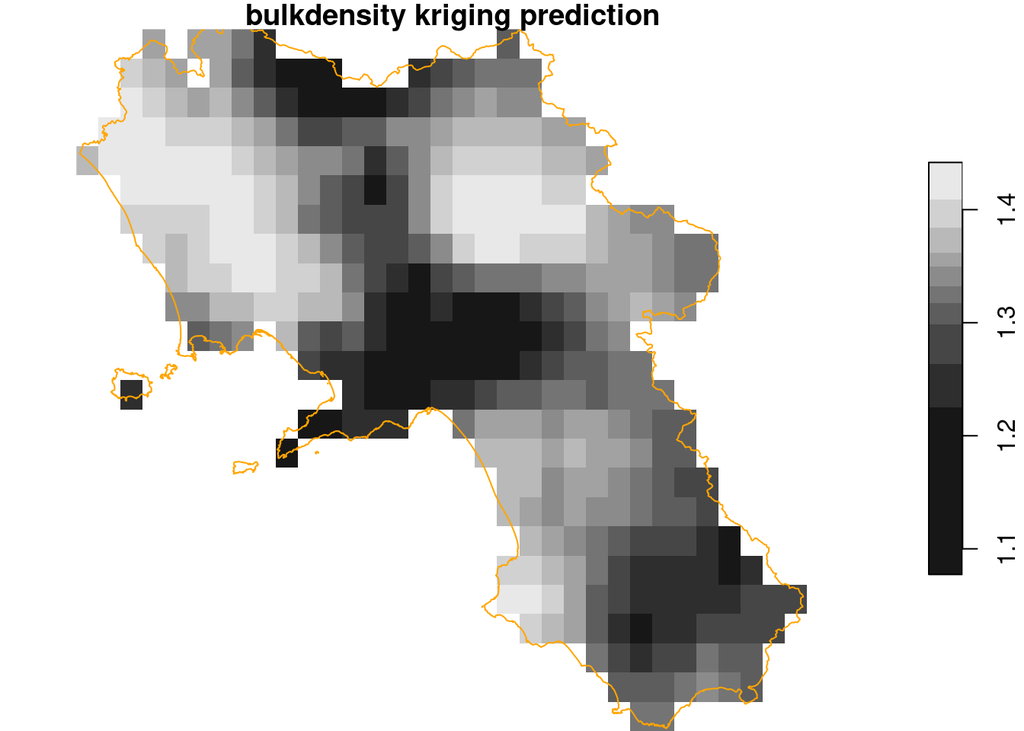

```r
plot(kr[1], reset = FALSE, main = "bulkdensity kriging prediction")
plot(st_geometry(roi), add = TRUE, col = NA, border = 'orange')
```

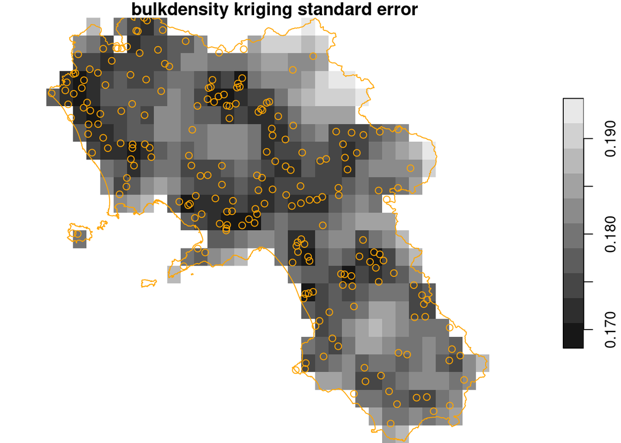

```r
kr$se = sqrt(kr$var1.var)
plot(kr["se"], reset = FALSE, breaks = "equal", main = "bulkdensity kriging standard error")
plot(st_geometry(roi), add = TRUE, col = NA, border = 'orange')
plot(st_geometry(s_nd), add = TRUE, col = 'orange')
```

### Doing this on a finer grid

We can create a finer (long/lat) grid, e.g. by creating a 0.01 x 0.01 **degree** raster:

```r
ra2 = st_as_stars(st_geometry(roi), dx = 0.01) |>
  st_crop(roi)
kr = krige(bulk_den~1, s_nd, ra2, v.fit)
```

```
## [using ordinary kriging]
```

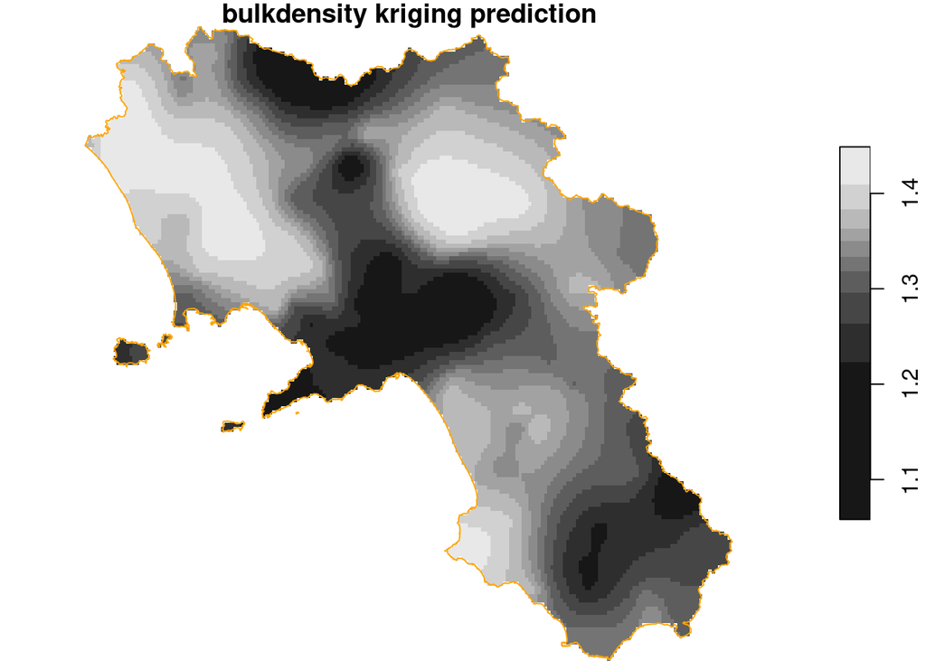

```r
plot(kr[1], reset = FALSE, main = "bulkdensity kriging prediction")
plot(st_geometry(roi), add = TRUE, col = NA, border = 'orange')
```

### Doing it properly, on a projected raster:

For instance, we can take UTM zone 33 N:

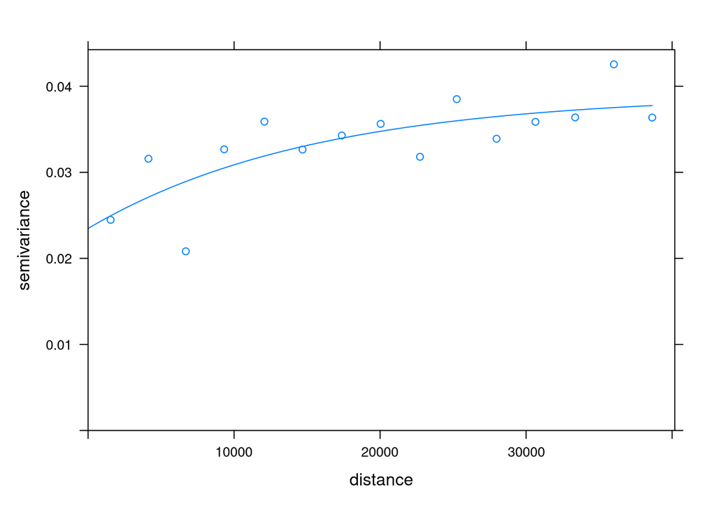

```r
utm33n = st_crs("EPSG:32633") # or: "+proj=utm +zone=33 +north"
roi_utm = st_transform(roi, utm33n)
s_utm = st_transform(s, utm33n)
v_utm = variogram(bulk_den~1, s_utm, cutoff = 40000) # cutoff now in m!
v_utm.fit = fit.variogram(v_utm, vgm(.01, "Exp", 15000, .02)) # fitted model
plot(v_utm, v_utm.fit) # is this O.K.?
```

We recreate a regular gird, now with grid cell size of 1 km:

```r
ra_utm = st_as_stars(st_geometry(roi_utm), dx = 1000) |>
  st_crop(roi_utm)
s_nd_utm = st_transform(s_nd, utm33n)
kr_utm = krige(bulk_den~1, s_nd_utm, ra_utm, v_utm.fit)
```

```
## [using ordinary kriging]
```

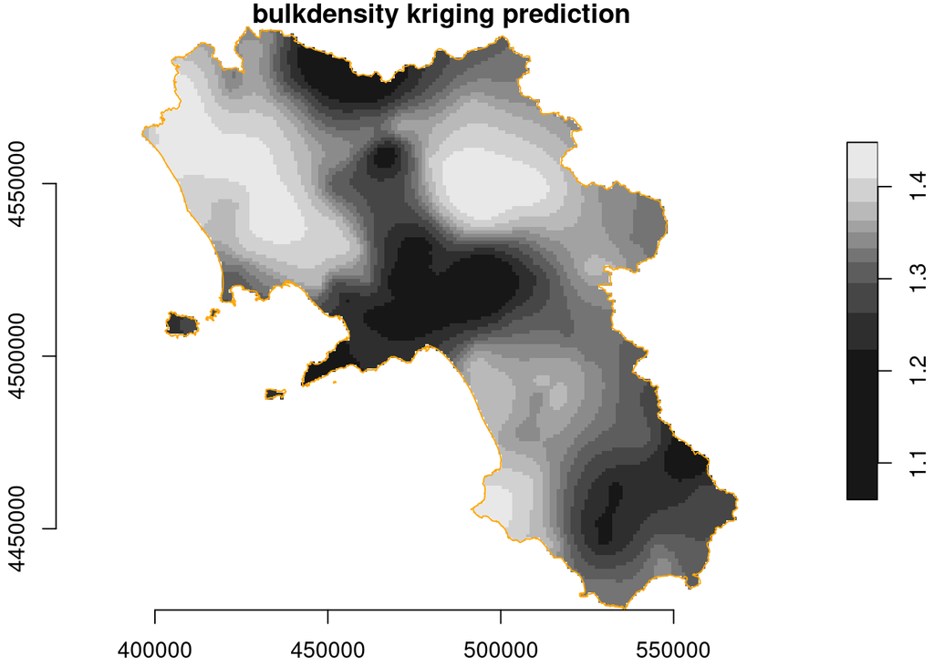

```r
plot(kr_utm[1], reset = FALSE, main = "bulkdensity kriging prediction", axes = TRUE)
plot(st_geometry(roi_utm), add = TRUE, col = NA, border = 'orange')
```

## Machine learning

see the stars vignette: https://r-spatial.github.io/stars/articles/stars7.html

## Exercises: geostatistics

1. Load the .Rmd and carry out (reproduce) the analysis above in your R session (Rstudio)
2. Repeat the analysis for another variable from the same soil dataset
3. Try fitting a spherical variogram model, and compare this to original results
4. Look up the meaning of the arguments `cutoff` and `width` of function `variogram`, vary their values, and try to understand what they mean